# CNN Cancer Detection - Kaggle Mini Project

Nick Vastine  
DTSA 5511 - Introduction to Deep Learning  
Week 3 Assignment  
March 25, 2025

## **Executive Summary**

This project explores Convolutional Neural Networks (CNN) in a cancer detection application. The project goal was to binary classify the presence of cancer in images of metastatic tissue. The dataset is sourced from the [Kaggle Histopathologic Cancer Detection Competition](https://www.kaggle.com/competitions/histopathologic-cancer-detection/).

The project is structured using a base model made up of a repeating convolution structure (convolution layers with subsampling convolution layers with stride as pooling layers) followed by a densely connected classification structure.

The base model first compares the effects of training with the full dataset (220,000+ images) or a balanced subset (50,000 images). Results indicated the balanced subset adequately described the dataset, without dramatic differences in model performance. The base model was then tuned, evaluating the effect of increasing batch size and number of training epochs. Increasing batch size yielded no improvement since the initial batch size sufficiently reduced noise, and the increased batch size meant a reduction in model updates. Increasing the number of epochs indicated when the model began overfitting.

The base model was then modified to represent alternative architectures. These modifications included replacing convolution subsampling with MaxPool, implementing batch normalization and droupout as regularization techniques, and creating a deeper network by increasing convolution filters and adding layers to the classifier structure. MaxPooling performed similar to the base model, which indicates MaxPooling was preferable since it is a simpler model. Regularization techniques surprisingly caused more overfitting, but poor experimental design cannot identify if batch norm, dropout, or both caused the issue. Finally the deeper model learned faster but without better performace, but also began to overfit more rapidly. Like MaxPooling, the simpler base model is superior to the deeper model for similar performance.

Future work could consider precise comparison between training sample variety and sample repetition (for example, 1 epoch of 20,0000 samples, or 4 epochs of 50,000 samples). Models can be improved with automatic learning rate reduction, and callbacks to stop training early could be implemented for efficiency. For future experimentation, a simpler model gradually built upon would be more insightful and faster to iterate than starting with a relatively complex model.

## **Problem Statement**

This project develops a neural network model to binary classify cancer presence in metastatic tissue images. The neural network implements convolution layers for feature detection in image processing applications.

The project compares performance training on the full dataset compared to a balanced subsample. The project also considers the effects of batch size and number of epochs on model effectiveness. Several neural network architectures are then compared to understand convolution layer effects such as pooling layers, regularization, and deeper learning alternatives.

Data is sourced from the [Kaggle Histopathologic Cancer Detection Competition](https://www.kaggle.com/competitions/histopathologic-cancer-detection/) which evaluates test data for accuracy. Base model performance is evaluated using the competition grader. Alternative models are evaluated relative to the base model based on training and validation metrics during model training.

## **Data**

The Kaggle project provides 4 sets of information:

- `Train` - A folder of 220,025 training images in *.tif* format.
- `Test` - A folder of 57,458 testing images in *.tif* format.
- `train_labels.csv` - A *.csv* of image id's and their respective labels. Labels: `{1: cancer, 0: no cancer}`.
- `sample_submission.csv` - A *.csv* of image id's and a label column of 0s to be filled during model prediction.

The below code imports both *.csv*'s to calculate the number of samples, then opens a single image to confirm its dimensions. All images are 96x96 pixels encoded in RGB.

```python
## Packages
import os
import time
import pandas as pd
import numpy as np
import matplotlib.pyplot as plt
import matplotlib.patches as patches
from PIL import Image
import tensorflow as tf
from tensorflow.keras import layers, models
```

```python
## Number of Samples
df_train = pd.read_csv('histopathologic-cancer-detection/train_labels.csv')
df_test = pd.read_csv('histopathologic-cancer-detection/sample_submission.csv')
test_samples = len(df_test)
train_samples = len(df_train)
print(f"Train Samples: {train_samples}")
print(f"Test Samples: {test_samples}")
```

```
Train Samples: 220025
Test Samples: 57458
```

```python
## Sample Image with Shape
id = df_train.id.iloc[0]                                               # Pick first image
im = Image.open('histopathologic-cancer-detection/train/'+id+'.tif')   # Open image
image_array = np.array(im)                                             # Convert to array
print("Image Dimensions:",image_array.shape)                           # Print array shape
im                                                                     # Show image
```

```
Image Dimensions: (96, 96, 3)
```

## **Exploratory Data Analysis**

### Image Samples

Before building our analysis, we will visually inspect a sample of the images for any obvious patterns. The below code samples 16 images from the training set and displays them with their cancer label.

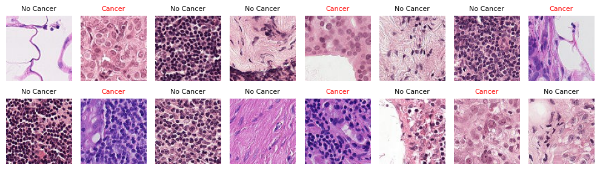

```python
## Labeled Sample Images

# Randomly sample 16 instances.
df_image_sample = df_train.sample(16)
# For each item, retrieve the image, label it in title, and plot on subplot.
fig, axs = plt.subplots(2, 8, figsize=(10,3))
title_label = ' '
for id, label, ax in zip(df_image_sample.id, df_image_sample.label, axs.flatten()):
    if label == 0:
        title_label = 'No Cancer'
        color_label = 'black'
    else:
        title_label = 'Cancer'
        color_label = 'red'
    im = Image.open('histopathologic-cancer-detection/train/'+id+'.tif') # Retrieve image
    ax.set_title(title_label,size=8,color=color_label)                   # Add label
    ax.imshow(im)                                                        # Show image
    ax.axis('off')                                                       # Turn off axis for each subplot
plt.tight_layout()
plt.show()
```

After sampling images a few times, there appear to be a few categories of contents:

1. White background which are quite sparce
2. Uniform distributions of cells
3. Swirls of material
4. Striations
5. Mis-shapen cells

The color of the images vary from a pale white, to purple, to a dark maroon. These colors do not seem to correlate with cancer presence. The shape of the cells may indicate cancer, such as variation circularity, or uniformity in shape.

It is not immediately apparent which images have cancer. Luckily, the neural network should learn the indicative features to classify cancer presence.

### Training and Testing Proportions

The below code determines the proportion of each class in the training set, returning a 60%/40% negative/positive split. The code also considers the proportion of training samples to testing samples, roughly 80%/20%.

This project compares the effect of training sample on model performance. A similarly structured model will train with all 220,000 training samples, while another model will use a balanced 50,000 sample subset.

Further comparative analysis on hyperparameters and alternative architectures will use the subsample for faster training.

```python
## Determining training/testing statistics
positive_samples = len(df_train[(df_train.label > 0)])
positive_percent = round(100*positive_samples/train_samples,2)
negative_samples = len(df_train[(df_train.label == 0)])
negative_percent = round(100*negative_samples/train_samples,2)
test_samples = len(df_test)
train_prop = round(100*train_samples/(train_samples + test_samples),2)
test_prop = round(100*test_samples/(train_samples + test_samples),2)

print(f"Train Samples: {train_samples}")
print(f"Positive Samples: {positive_samples} or {positive_percent}%")
print(f"Negative Samples: {negative_samples} or {negative_percent}%")
print(f"Test Samples: {test_samples}")
print(f"Train Proportion: {train_prop}% / Test Proportion: {test_prop}%")
```

```
Train Samples: 220025
Positive Samples: 89117 or 40.5%
Negative Samples: 130908 or 59.5%
Test Samples: 57458
Train Proportion: 79.29% / Test Proportion: 20.71%
```

### Image Crop

```python
## Example 32x32 boundary

# Create figure and axes
fig, ax = plt.subplots(figsize=(1,1))
# Display the image
ax.imshow(im)
# Create rectangle and draw on image
width, height = im.size
dim = 32
rect = patches.Rectangle((width/2-dim/2, height/2-dim/2), dim, dim, linewidth=1, edgecolor='r', facecolor='none')
ax.add_patch(rect)
ax.axis('off')

plt.show()
```

[output not shown]

We are able to crop the images to their center to reduce memory demands. This may sufficiently reduce the data to load the information in full rather than incrementally process images during training.

This process is quite time intensive but only needs to be processed once.

```python
## Image Crop and Saving
initial_size = 0
final_size = 0
i = 0
for dirpath, subdirs, files in os.walk('histopathologic-cancer-detection/train/', topdown=True): # This code walks through all paths within a directory
    for file in files: # for each file in the directory
        if file.endswith(".tif"): # if an image
            i += 1
            img = Image.open(os.path.join(dirpath, file)) # open image
            initial_size += os.path.getsize(os.path.join(dirpath, file))
            width, height = img.size
            cropped_img = img.crop((height/2-16, width/2-16, width/2+16, height/2+16))
            new_path = 'histopathologic-cancer-detection/train_crop/'+str(file)[:-3]+'png'
            cropped_img.save(new_path)
            final_size += os.path.getsize(new_path)
        if i % 10000 == 0:
            print(f"{i} images complete!")
print("Crop Complete!")
print(f"Initial size: {round(initial_size/(1024*1024),2)}MB")
print(f"Final size: {round(final_size/(1024*1024),2)}MB")
```

```
10000 images complete!
20000 images complete!
30000 images complete!
40000 images complete!
50000 images complete!
60000 images complete!
70000 images complete!
80000 images complete!
90000 images complete!
100000 images complete!
110000 images complete!
120000 images complete!
130000 images complete!
140000 images complete!
150000 images complete!
160000 images complete!
170000 images complete!
180000 images complete!
190000 images complete!
200000 images complete!
210000 images complete!
220000 images complete!
Crop Complete!
Initial size: 5861.66MB
Final size: 562.61MB
```

```python
## Image Crop and Saving - Test Data
initial_size = 0
final_size = 0
i = 0
for dirpath, subdirs, files in os.walk('histopathologic-cancer-detection/test/', topdown=True): # This code walks through all paths within a directory
    for file in files: # for each file in the directory
        if file.endswith(".tif"): # if an image
            i += 1
            img = Image.open(os.path.join(dirpath, file)) # open image
            initial_size += os.path.getsize(os.path.join(dirpath, file))
            width, height = img.size
            cropped_img = img.crop((height/2-16, width/2-16, width/2+16, height/2+16))
            new_path = 'histopathologic-cancer-detection/test_crop/'+str(file)[:-3]+'png'
            cropped_img.save(new_path)
            final_size += os.path.getsize(new_path)
        if i % 10000 == 0:
            print(f"{i} images complete!")
print("Crop Complete!")
print(f"Initial size: {round(initial_size/(1024*1024),2)}MB")
print(f"Final size: {round(final_size/(1024*1024),2)}MB")
```

```
10000 images complete!
20000 images complete!
30000 images complete!
40000 images complete!
50000 images complete!
Crop Complete!
Initial size: 1530.73MB
Final size: 146.37MB
```

### Convert to subsampled, balanced training array

The below code generates the aforementioned balanced subsample for model training. The subsample will be used to compare to our full training set, and speed up training during hyperparameter tuning and when evaluating alternative architectures.

Both the full training set and subsampled training set are consolidated into numpy arrays we can feed into our model.

```python
## Subsample Dataframe
df_train_subsample_positive = df_train[df_train.label > 0].sample(25000, random_state = 42)
df_train_subsample_negative = df_train[df_train.label == 0].sample(25000, random_state = 42)
df_train_subsample = pd.concat([df_train_subsample_positive,df_train_subsample_negative], axis=0)
df_train_subsample = df_train_subsample.sample(len(df_train_subsample), random_state = 42).reset_index(drop=True)
```

```python
## Generating data from images
i = 0
X = np.empty((len(df_train_subsample), 32, 32, 3))
for id in df_train_subsample.id:
    img = Image.open('histopathologic-cancer-detection/train_crop/'+id+'.png')
    img = np.asarray(img) # Convert to array
    # img = img/255 # rescale from 0-255 to 0-1
    X[i] = img # append to our dataset
    i += 1 # increment the index
Y = df_train_subsample['label'].values
```

```python
## Generating data from images - Full data
i = 0
X_full = np.empty((len(df_train), 32, 32, 3))
for id in df_train.id:
    img = Image.open('histopathologic-cancer-detection/train_crop/'+id+'.png')
    img = np.asarray(img) # Convert to array
    # img = img/255 # rescale from 0-255 to 0-1
    X_full[i] = img # append to our dataset
    i += 1 # increment the index
Y_full = df_train['label'].values
```

```python
## Generating data from images - Test data
i = 0
X_test = np.empty((len(df_test), 32, 32, 3))
for id in df_test.id:
    img = Image.open('histopathologic-cancer-detection/test_crop/'+id+'.png')
    img = np.asarray(img) # Convert to array
    # img = img/255 # rescale from 0-255 to 0-1
    X_test[i] = img # append to our dataset
    i += 1 # increment the index
# Y_test = df_test['label'].values
```

```python
## Exporting data to numpy file format
np.save('X.npy', X)
np.save('X_full.npy', X_full)
np.save('X_test.npy', X_test)
```

```python
## Reading numpy files - just in case
X = np.load('X.npy')
X_full = np.load('X_full.npy')
X_test = np.load('X_test.npy')
```

### Histogram Analysis

The subsampled training data array is used to generate histograms for intensity and color for each class. The top histograms are samples with cancer (label = 1) and below are samples without cancer (label = 0).

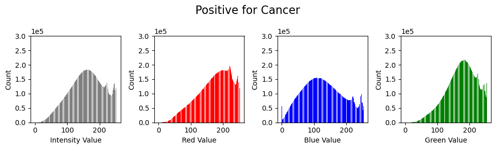

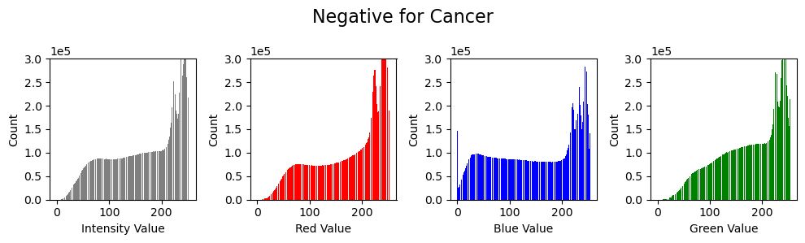

```python
## Distribution Analysis and Plotting Functions
def color_arrays(data):
    intensity_array = np.sum(data,axis=3)/3
    red_array = data[:,:,:,0]
    blue_array = data[:,:,:,1]
    green_array = data[:,:,:,2]
    return intensity_array, red_array, blue_array, green_array

def color_hist(intensity_array, red_array, blue_array, green_array):
    bins=np.arange(0, 255)
    intensity_hist, _ = np.histogram(intensity_array.flatten(), bins=bins)
    red_hist, _ = np.histogram(red_array.flatten(), bins=bins)
    blue_hist, _ = np.histogram(blue_array.flatten(), bins=bins)
    green_hist, _ = np.histogram(green_array.flatten(), bins=bins)
    return intensity_hist, red_hist, blue_hist, green_hist

def plot_hist(intensity_hist, red_hist, blue_hist, green_hist, title):
    bins=np.arange(0, 254)
    ylim = 300000
    fig, axs = plt.subplots(1, 4, figsize=(10, 3))
    fig.tight_layout()
    fig.suptitle(title, size=16, fontweight=4)
    axs[0].ticklabel_format(axis='y', style='sci',scilimits=(0,0))
    axs[0].bar(bins, intensity_hist, color="grey")
    axs[0].set_ylim([0, ylim])
    axs[0].set_xlabel("Intensity Value")
    axs[0].set_ylabel("Count")

    axs[1].ticklabel_format(axis='y', style='sci',scilimits=(0,0))
    axs[1].bar(bins, red_hist, color="red")
    axs[1].set_ylim([0, ylim])
    axs[1].set_xlabel("Red Value")
    axs[1].set_ylabel("Count")

    axs[2].ticklabel_format(axis='y', style='sci',scilimits=(0,0))
    axs[2].bar(bins, blue_hist, color="blue")
    axs[2].set_ylim([0, ylim])
    axs[2].set_xlabel("Blue Value")
    axs[2].set_ylabel("Count")

    axs[3].ticklabel_format(axis='y', style='sci',scilimits=(0,0))
    axs[3].bar(bins, green_hist, color="green")
    axs[3].set_ylim([0, ylim])
    axs[3].set_xlabel("Green Value")
    axs[3].set_ylabel("Count")

    plt.tight_layout()

### Positive for Cancer
intensity_array, red_array, blue_array, green_array = color_arrays(X[Y==1])
intensity_hist, red_hist, blue_hist, green_hist = color_hist(intensity_array, red_array, blue_array, green_array)
plot_hist(intensity_hist, red_hist, blue_hist, green_hist, "Positive for Cancer")

### Negative for Cancer
intensity_array, red_array, blue_array, green_array = color_arrays(X[Y==0])
intensity_hist, red_hist, blue_hist, green_hist = color_hist(intensity_array, red_array, blue_array, green_array)
plot_hist(intensity_hist, red_hist, blue_hist, green_hist, "Negative for Cancer")
```

In color encoding, an RGB value of [255, 255, 255] represents white. As such, histograms skewed toward higher values represent images which are lighter. Interestingly, the histograms for images without cancer are skewed to higher values. These may be the sparse, pale white images without many cells that could be cancerous. Images positive for cancer are more centrally distributed than those negative for cancer, though still showing varying degrees of skew and kurtosis.

These histograms could serve as good features for other machine learning strategies. However, they are not relevant to our study of convolutional layers from image data. If you are curious about using these features in unsupervised learning applications, consider my Github project performing fruit classification using image-specific histograms as the basis of feature selection.

## **Model Architecture**

The neural model will use the following structure, which is justified below.

1. Input layer of image (32x32x3)
2. Convolution Structure #1
   1. Convolution layer - 3x3 kernel, 16 filters
   2. Subsampling Convolution layer - 2x2 kernel, stride (2,2)
3. Convolution Structure #2
   1. Convolution layer - 3x3 kernel, 32 filters
   2. Subsampling Convolution layer - 2x2 kernel, stride (2,2)
4. Convolution Structure #3
   1. Convolution layer - 3x3 kernel, 64 filters
   2. Subsampling Convolution layer - 2x2 kernel, stride (2,2)
5. Classifier Structure
   1. Dense Layer - 128 neurons - ReLU
   2. Dense Layer - 64 neurons - ReLU
   3. Dense Layer - 32 neurons - ReLU
   4. Binary classification layer - Sigmoid

The convolution structure is made of two parts, the convolution layer and the pooling/subsampling layer. We can repeat this structure to identify increasingly complex features in the data.

The convolution layer has a variety of hyperparameters to consider such as the size of the kernel/filter, number of filters, padding, and stride. Each parameter for the initial model is addressed in turn:

1. `kernel_size = (3,3)` - Odd kernel sizes ensure the convolution operation is centered on the representative pixel. Smaller kernels also detect smaller structures in the image, which is essential to construct larger structures later in the network.
2. `filters = 16, 32, 64` - Filters are set arbitrarily, starting with half the dimensions of the image and increasing to learn more complex patterns from primitives later in the network.
3. `padding = 'same'` - Adding padding ensures no data loss at the edges of the image.
4. `strides = (1,1) [default]` - Default stride to similarly avoid data loss.
5. `activation = 'relu'` - Add non-linearity to our kernel parameters

The pooling/subsampling function can be performed using Max Pooling, Average Pooling, or using another convolution layer with stride to subsample points from the previous layer. My machine learning course mentions that convolution layers with stride create learnable parameters which can improve accuracy relative to strict pooling methods which simply return the average or max value. As such, the model will perform convolution with stride for its pooling operation.

This convolution structure is repeated three times, which is hopefully sufficient to capture complex patterns. After the third layer, the 64 filters x 4x4 matrices is flattened and passed to a densely connected neural network. The first layer has 128 neurons, equal to one eighth of the incoming data from the convolution layers. The number of neurons are halved in 2 subsequent classifier layers before passing to our sigmoid classifier at the end of the neural network.

### Constructing the neural network

Below builds the architecture of the initial model using the `keras` framework. This includes compiling our optimizer (`Adam`), loss model (`binary_crossentropy`). The models will be compared using accuracy, recall, precision, and the model loss.

```python
## Create the neural network model
base_model = models.Sequential()
# Input layer with cropping
base_model.add(layers.Input(shape=(32,32,3)))
# Three repeating substructures: Convolution + Subsampling Convolution
for filter in [16, 32, 64]:
    base_model.add(layers.Conv2D(filters=filter, kernel_size=(3, 3), padding='same', activation='relu'))
    base_model.add(layers.Conv2D(filters=filter, kernel_size=(2, 2), strides=(2,2), activation='relu'))
# Flatten and connect to dense layers
base_model.add(layers.Flatten())
base_model.add(layers.Dense(128, activation='relu'))
base_model.add(layers.Dense(64, activation='relu'))
base_model.add(layers.Dense(32, activation='relu'))
# Output classification layer with sigmoid activation
base_model.add(layers.Dense(1, activation='sigmoid'))
# Compile model
base_model.compile(
    optimizer = tf.keras.optimizers.Adam(learning_rate = 0.001),
    loss = 'binary_crossentropy',
    metrics = ['accuracy','recall','precision'])

# Print model summary
base_model.summary()
```

```
Model: "sequential_1"
```

```
┏━━━━━━━━━━━━━━━━━━━━━━━━━━━━━━━━━━━━━━┳━━━━━━━━━━━━━━━━━━━━━━━━━━━━━┳━━━━━━━━━━━━━━━━━┓
┃ Layer (type)                         ┃ Output Shape                ┃         Param # ┃
┡━━━━━━━━━━━━━━━━━━━━━━━━━━━━━━━━━━━━━━╇━━━━━━━━━━━━━━━━━━━━━━━━━━━━━╇━━━━━━━━━━━━━━━━━┩
│ conv2d_6 (Conv2D)                    │ (None, 32, 32, 16)          │             448 │
├──────────────────────────────────────┼─────────────────────────────┼─────────────────┤
│ conv2d_7 (Conv2D)                    │ (None, 16, 16, 16)          │           1,040 │
├──────────────────────────────────────┼─────────────────────────────┼─────────────────┤
│ conv2d_8 (Conv2D)                    │ (None, 16, 16, 32)          │           4,640 │
├──────────────────────────────────────┼─────────────────────────────┼─────────────────┤
│ conv2d_9 (Conv2D)                    │ (None, 8, 8, 32)            │           4,128 │
├──────────────────────────────────────┼─────────────────────────────┼─────────────────┤
│ conv2d_10 (Conv2D)                   │ (None, 8, 8, 64)            │          18,496 │
├──────────────────────────────────────┼─────────────────────────────┼─────────────────┤
│ conv2d_11 (Conv2D)                   │ (None, 4, 4, 64)            │          16,448 │
├──────────────────────────────────────┼─────────────────────────────┼─────────────────┤
│ flatten_1 (Flatten)                  │ (None, 1024)                │               0 │
├──────────────────────────────────────┼─────────────────────────────┼─────────────────┤
│ dense_5 (Dense)                      │ (None, 128)                 │         131,200 │
├──────────────────────────────────────┼─────────────────────────────┼─────────────────┤
│ dense_6 (Dense)                      │ (None, 64)                  │           8,256 │
├──────────────────────────────────────┼─────────────────────────────┼─────────────────┤
│ dense_7 (Dense)                      │ (None, 32)                  │           2,080 │
├──────────────────────────────────────┼─────────────────────────────┼─────────────────┤
│ dense_8 (Dense)                      │ (None, 1)                   │              33 │
└──────────────────────────────────────┴─────────────────────────────┴─────────────────┘
```

```
 Total params: 186,769 (729.57 KB)
```

```
 Trainable params: 186,769 (729.57 KB)
```

```
 Non-trainable params: 0 (0.00 B)
```

### Model Training and Evaluation

The model will be judged using test AUC provided from the Kaggle Competition data grader. Note the intent of this project is not to maximimze AUC in this competition, but to understand the modification on CNN model performance.

Accuracy, recall, loss and precision evaluate model performance through epochs of training. The model are trained for `epochs=20` with `batch_size=1000` unless otherwise noted. `validation_split=0.05` indicates 5% of the training data serves as validation data to track overfitting effects. Data is scaled from 0-255 to 0-1 before being fed to the model.

```python
## Model Evaluation Function

def model_evaluation(model, train=X, label=Y, epochs=20, batch_size=1000):
    '''
    Function which takes an untrained base model, trains it, and returns time to train, model, and log for further analysis.
    Log can be used in epoch_plots function to visualize train/validation progress over epochs.
    '''
    start = time.time()
    clone_model = models.clone_model(model)
    log = clone_model.fit(train/255, label,
                              epochs = epochs,
                              validation_split=0.05,
                              batch_size = batch_size,
                              verbose=0)
    duration = time.time()-start
    accuracy = log.history['accuracy'][-1]
    val_accuracy = log.history['val_accuracy'][-1]
    ## Print results
    print(f"  Duration:{round(duration,1)}s, Accuracy:{round(accuracy,3)}, Val Accuracy: {round(val_accuracy,3)}")
    return clone_model, log
```

```python
## Model Training - Subsample

print("Base Model Trained using Subsample")
base_subsample_model, base_subsample_log  = model_evaluation(base_model)
```

```
Base Model Trained using Subsample
  Duration:166.2s, Accuracy:0.814, Val Accuracy: 0.804
```

```python
## Model Training - Full

print("Base Model Trained using Full Training Data")
base_full_model, base_full_log = model_evaluation(base_model, train=X_full, label=Y_full)
```

```
Base Model Trained using Full Training Data
  Duration:756.8s, Accuracy:0.85, Val Accuracy: 0.817
```

## **Results & Analysis**

### Base model results

Before we submit to the competition, we can evaluate our model performance by plotting the accuracy, recall, loss and precision over its training epochs. This could indicate overfitting we should mitigate before submitting to the competition.

```python
## Epoch Plot Function
def epoch_plots(log,suptitle=""):
    '''
    Plots accuracy, precision, recall and loss from model log.
    '''
    params = [log.history['accuracy'],
              log.history.get('precision', []),
              log.history.get('recall', []),
              log.history['loss']]
    val_params = [log.history['val_accuracy'],
                  log.history.get('val_precision', []),
                  log.history.get('val_recall', []),
                  log.history['val_loss']]
    labels = ['Accuracy',
              'Precision',
              'Recall',
              'Binary Cross Entropy Loss']
    epochs = range(1, len(log.history['accuracy']) + 1)  # Epoch numbers

    # Plotting
    fig, axes = plt.subplots(1, 4, figsize=(20, 4))
    for ax, param, val_param, label in zip(axes.flatten(),params,val_params,labels):
        ax.plot(epochs, param, label='Training', marker='o')
        ax.plot(epochs, val_param, label='Validation', marker='o')
        ax.set_title(label+' vs Epochs')
        ax.set_xlabel('Epochs')
        ax.set_ylabel(label)
        ax.set_ylim([0,1])
        ax.legend(loc='lower left')
        ax.grid(True)
    fig.suptitle(suptitle, fontweight="bold")
    plt.tight_layout()
    plt.show()
```

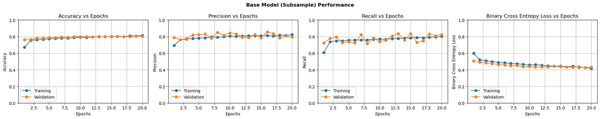

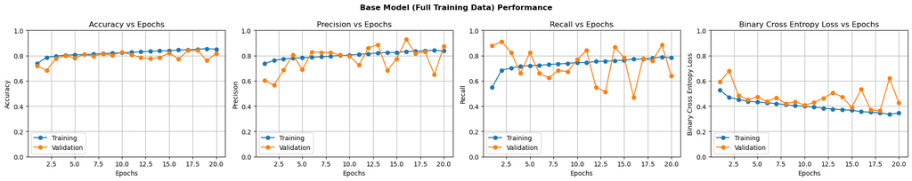

```python
epoch_plots(base_subsample_log, suptitle = "Base Model (Subsample) Performance")
epoch_plots(base_full_log, suptitle = "Base Model (Full Training Data) Performance")
```

The plots indicate some important trends:

- *Duration* - Unsurprisingly, the model with more data points to evaluate took longer to train. What is surprising is the increase in training duration was proportional to the increase in the number of points, about a 4.4x increase.
- *Rate of improvement* - The full data model improves faster than the subsampled data model. However, this is because an epoch is inconsistent between models. Taking this into account, the full data model at 5 epochs is similar to the subsampled model at 20 epochs after both have seen a similar number of samples.
- *Accuracy* - Both the full training data and subsampled models incrementally improve in accuracy, not quite plateauing after 20 epochs. The full training model has higher training accuracy as a result of seeing 4.4x as many points. There is no clear indication of overfitting, though it may be masked by instability seen in the full data model. Unlike the subsample model, the full data model has with dramatic swings in validation.
- *Loss* - Like accuracy, both models appear to improve incrementally at first, though the full data model clearly has more oscillation. As with accuracy, the model trained on full data dramatically oscillates starting at epoch 10, indicating model stability concerns.
- *Recall and Precision* - Like loss, the full model more severely oscillates compared to the subsampled model. This too may indicate model instability or overfitting, supported by the other plots.

While stability improvements will not be tested in this project, one may consider regularization techniques or scheduled reductions in learning rates to reduce the instablility in the full data model training.

### Model Prediction - Kaggle Evaluation

The following code generates predictions for the Kaggle competition test data, which is saved to a *.csv* file for submission.

```python
## Model Prediction
Y_base_subsample_prediction = base_subsample_model.predict(X_test/255)
Y_base_full_prediction = base_full_model.predict(X_test/255)
```

```
1796/1796 ━━━━━━━━━━━━━━━━━━━━ 4s 2ms/step
1796/1796 ━━━━━━━━━━━━━━━━━━━━ 5s 3ms/step
```

```python
## Saving Results for Submission
# df_test copy
df_test_base = df_test.copy()
# Save for subsample
df_test_base['label'] = np.round(Y_base_subsample_prediction,0)
df_test_base.to_csv('Base Model (Subsample) Predictions.csv', index=False)
# Save for full data
df_test_base['label'] = np.round(Y_base_full_prediction,0)
df_test_base.to_csv('Base Model (Full Training Data) Predictions.csv', index=False)
print("Files saved!")
```

```
Files saved!
```

The subsample model scored `0.7776` from the Kaggle Competition, while the full-data model scored `0.7462`.

Generally AUC > 0.8 is good, AUC > 0.9 is excellent. While not the especially impressive, we are able to establish a performance baseline to test model modifications against.

#### Batch Size and Epochs Tuning

Recall the subsample base model is trained using 20 epochs and a batch size of 1000. Let's consider the effects of these hyperparameters on model performance:

- *Increase batch size from 1000 to 5000* - Larger batches reduce noise in gradient calculation, ideally reducing instability concerns.
- *Double number of epochs from 20 to 40* - Additional epochs allow the model to train longer, which may improve performance until the model begins overfitting.

```python
print('Base Model (5x Batch Size)')
base_model_20_5000, log_20_5000 = model_evaluation(base_model, epochs=20, batch_size = 5000)
```

```
Base Model (5x Batch Size)
  Duration:133.3s, Accuracy:0.773, Val Accuracy: 0.774
```

```python
print('Base Model (Doubled Epochs)')
base_model_40_1000, log_40_1000 = model_evaluation(base_model, epochs=40, batch_size = 1000)
```

```
Base Model (Doubled Epochs)
  Duration:270.8s, Accuracy:0.915, Val Accuracy: 0.766
```

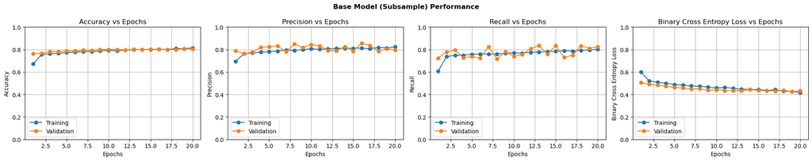

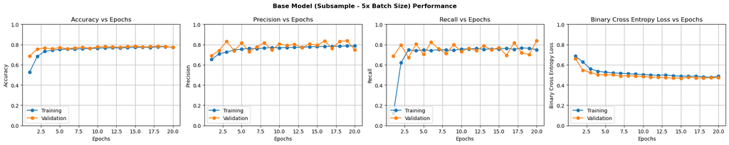

[figure not shown]

```python
epoch_plots(base_subsample_log, suptitle = "Base Model (Subsample) Performance")
epoch_plots(log_20_5000, suptitle = "Base Model (Subsample - 5x Batch Size) Performance")
epoch_plots(log_40_1000, suptitle = "Base Model (Subsample - 2x Epoch) Performance")
```

The larger batch size did not dramatically affect the results. Accuracy decreased since there are fewer updates to model weights with fewer overall batches. It is not recommended to increase batch size for this model since it did not improve model performance and is more memory intensive.

Tuning training hyperparameters or increasing training time can improve a model, though more dramatic improvements may result from alternative model architectures.

### Alternative Architectures

This project will evaluate three modifications to the base model architecture to evaluate their effects:

- Replacing stride subsampling with max pooling layers
- Adding batch normization between convolution layers and dropout between dense layers as regularization methods
- Increasing the complexity of the network with more convolution layer filters and additional dense layers

The models will be trained using the subsample of data. The models use 40 epochs to ensure overtraining with the 1000 sample batch size.

#### Max Pooling

The base model's subsampling convolution layer provides more parameters during model training. These additional parameters may improve accuracy, but are more computationally expensive and may overfit training data. Max pooling instead uses the maximum value within the pool from the previous convolutional layer, which may highlight the most important/influential features.

```python
## Max Pooling
## Create the neural network model
max_pool_model = models.Sequential()
# Input layer with cropping
max_pool_model.add(layers.Input(shape=(32,32,3)))
# Three repeating substructures: Convolution + Subsampling Convolution
for filter in [16, 32, 64]:
    max_pool_model.add(layers.Conv2D(filters=filter, kernel_size=(3, 3), padding='same', activation='relu'))
    max_pool_model.add(layers.MaxPooling2D(pool_size=(2, 2), strides=(2, 2), padding='valid'))
# Flatten and connect to dense layers
max_pool_model.add(layers.Flatten())
max_pool_model.add(layers.Dense(128, activation='relu'))
max_pool_model.add(layers.Dense(64, activation='relu'))
max_pool_model.add(layers.Dense(32, activation='relu'))
# Output classification layer with sigmoid activation
max_pool_model.add(layers.Dense(1, activation='sigmoid'))
# Compile model
max_pool_model.compile(
    optimizer = tf.keras.optimizers.Adam(learning_rate = 0.001),
    loss = 'binary_crossentropy',
    metrics = ['accuracy','recall','precision'])

# Print model summary
max_pool_model.summary()
```

```
Model: "sequential_2"
```

```
┏━━━━━━━━━━━━━━━━━━━━━━━━━━━━━━━━━━━━━━┳━━━━━━━━━━━━━━━━━━━━━━━━━━━━━┳━━━━━━━━━━━━━━━━━┓
┃ Layer (type)                         ┃ Output Shape                ┃         Param # ┃
┡━━━━━━━━━━━━━━━━━━━━━━━━━━━━━━━━━━━━━━╇━━━━━━━━━━━━━━━━━━━━━━━━━━━━━╇━━━━━━━━━━━━━━━━━┩
│ conv2d_12 (Conv2D)                   │ (None, 32, 32, 16)          │             448 │
├──────────────────────────────────────┼─────────────────────────────┼─────────────────┤
│ max_pooling2d (MaxPooling2D)         │ (None, 16, 16, 16)          │               0 │
├──────────────────────────────────────┼─────────────────────────────┼─────────────────┤
│ conv2d_13 (Conv2D)                   │ (None, 16, 16, 32)          │           4,640 │
├──────────────────────────────────────┼─────────────────────────────┼─────────────────┤
│ max_pooling2d_1 (MaxPooling2D)       │ (None, 8, 8, 32)            │               0 │
├──────────────────────────────────────┼─────────────────────────────┼─────────────────┤
│ conv2d_14 (Conv2D)                   │ (None, 8, 8, 64)            │          18,496 │
├──────────────────────────────────────┼─────────────────────────────┼─────────────────┤
│ max_pooling2d_2 (MaxPooling2D)       │ (None, 4, 4, 64)            │               0 │
├──────────────────────────────────────┼─────────────────────────────┼─────────────────┤
│ flatten_2 (Flatten)                  │ (None, 1024)                │               0 │
├──────────────────────────────────────┼─────────────────────────────┼─────────────────┤
│ dense_9 (Dense)                      │ (None, 128)                 │         131,200 │
├──────────────────────────────────────┼─────────────────────────────┼─────────────────┤
│ dense_10 (Dense)                     │ (None, 64)                  │           8,256 │
├──────────────────────────────────────┼─────────────────────────────┼─────────────────┤
│ dense_11 (Dense)                     │ (None, 32)                  │           2,080 │
├──────────────────────────────────────┼─────────────────────────────┼─────────────────┤
│ dense_12 (Dense)                     │ (None, 1)                   │              33 │
└──────────────────────────────────────┴─────────────────────────────┴─────────────────┘
```

```
 Total params: 165,153 (645.13 KB)
```

```
 Trainable params: 165,153 (645.13 KB)
```

```
 Non-trainable params: 0 (0.00 B)
```

```python
print("Max Pool Model")
max_pool_model, max_pool_log = model_evaluation(max_pool_model, epochs=40, batch_size = 1000)
```

```
Max Pool Model
  Duration:217.2s, Accuracy:0.878, Val Accuracy: 0.767
```

#### Regularization

The regularization model adds batch normalization between the convolution layers and dropout between the dense layers in the classifier structure. Both modifications intend to reduce overfitting, either by improving neuron stablity and some additional learning parameters, or by creating neuron redundancy and distributing the updates during training.

```python
## Regularization
## Create the neural network model
regularization_model = models.Sequential()
# Input layer with cropping
regularization_model.add(layers.Input(shape=(32,32,3)))
# Three repeating substructures: Convolution + Subsampling Convolution
for filter in [16, 32, 64]:
    regularization_model.add(layers.Conv2D(filters=filter, kernel_size=(3, 3), padding='same'))
    regularization_model.add(layers.BatchNormalization())
    regularization_model.add(layers.Activation('relu'))
    regularization_model.add(layers.Conv2D(filters=filter, kernel_size=(2, 2), strides=(2,2), activation='relu'))
# Flatten and connect to dense layers
regularization_model.add(layers.Flatten())
for neurons in [128, 64, 32]:
    regularization_model.add(layers.Dense(neurons, activation='relu'))
    regularization_model.add(layers.Dropout(rate = 0.2))
# Output classification layer with sigmoid activation
regularization_model.add(layers.Dense(1, activation='sigmoid'))
# Compile model
regularization_model.compile(
    optimizer = tf.keras.optimizers.Adam(learning_rate = 0.001),
    loss = 'binary_crossentropy',
    metrics = ['accuracy','recall','precision'])

# Print model summary
regularization_model.summary()
```

```
Model: "sequential_3"
```

```
┏━━━━━━━━━━━━━━━━━━━━━━━━━━━━━━━━━━━━━━┳━━━━━━━━━━━━━━━━━━━━━━━━━━━━━┳━━━━━━━━━━━━━━━━━┓
┃ Layer (type)                         ┃ Output Shape                ┃         Param # ┃
┡━━━━━━━━━━━━━━━━━━━━━━━━━━━━━━━━━━━━━━╇━━━━━━━━━━━━━━━━━━━━━━━━━━━━━╇━━━━━━━━━━━━━━━━━┩
│ conv2d_15 (Conv2D)                   │ (None, 32, 32, 16)          │             448 │
├──────────────────────────────────────┼─────────────────────────────┼─────────────────┤
│ batch_normalization                  │ (None, 32, 32, 16)          │              64 │
│ (BatchNormalization)                 │                             │                 │
├──────────────────────────────────────┼─────────────────────────────┼─────────────────┤
│ activation (Activation)              │ (None, 32, 32, 16)          │               0 │
├──────────────────────────────────────┼─────────────────────────────┼─────────────────┤
│ conv2d_16 (Conv2D)                   │ (None, 16, 16, 16)          │           1,040 │
├──────────────────────────────────────┼─────────────────────────────┼─────────────────┤
│ conv2d_17 (Conv2D)                   │ (None, 16, 16, 32)          │           4,640 │
├──────────────────────────────────────┼─────────────────────────────┼─────────────────┤
│ batch_normalization_1                │ (None, 16, 16, 32)          │             128 │
│ (BatchNormalization)                 │                             │                 │
├──────────────────────────────────────┼─────────────────────────────┼─────────────────┤
│ activation_1 (Activation)            │ (None, 16, 16, 32)          │               0 │
├──────────────────────────────────────┼─────────────────────────────┼─────────────────┤
│ conv2d_18 (Conv2D)                   │ (None, 8, 8, 32)            │           4,128 │
├──────────────────────────────────────┼─────────────────────────────┼─────────────────┤
│ conv2d_19 (Conv2D)                   │ (None, 8, 8, 64)            │          18,496 │
├──────────────────────────────────────┼─────────────────────────────┼─────────────────┤
│ batch_normalization_2                │ (None, 8, 8, 64)            │             256 │
│ (BatchNormalization)                 │                             │                 │
├──────────────────────────────────────┼─────────────────────────────┼─────────────────┤
│ activation_2 (Activation)            │ (None, 8, 8, 64)            │               0 │
├──────────────────────────────────────┼─────────────────────────────┼─────────────────┤
│ conv2d_20 (Conv2D)                   │ (None, 4, 4, 64)            │          16,448 │
├──────────────────────────────────────┼─────────────────────────────┼─────────────────┤
│ flatten_3 (Flatten)                  │ (None, 1024)                │               0 │
├──────────────────────────────────────┼─────────────────────────────┼─────────────────┤
│ dense_13 (Dense)                     │ (None, 128)                 │         131,200 │
├──────────────────────────────────────┼─────────────────────────────┼─────────────────┤
│ dropout (Dropout)                    │ (None, 128)                 │               0 │
├──────────────────────────────────────┼─────────────────────────────┼─────────────────┤
│ dense_14 (Dense)                     │ (None, 64)                  │           8,256 │
├──────────────────────────────────────┼─────────────────────────────┼─────────────────┤
│ dropout_1 (Dropout)                  │ (None, 64)                  │               0 │
├──────────────────────────────────────┼─────────────────────────────┼─────────────────┤
│ dense_15 (Dense)                     │ (None, 32)                  │           2,080 │
├──────────────────────────────────────┼─────────────────────────────┼─────────────────┤
│ dropout_2 (Dropout)                  │ (None, 32)                  │               0 │
├──────────────────────────────────────┼─────────────────────────────┼─────────────────┤
│ dense_16 (Dense)                     │ (None, 1)                   │              33 │
└──────────────────────────────────────┴─────────────────────────────┴─────────────────┘
```

```
 Total params: 187,217 (731.32 KB)
```

```
 Trainable params: 186,993 (730.44 KB)
```

```
 Non-trainable params: 224 (896.00 B)
```

```python
## Model Fit
print("Regularization Model")
regularization_model, regularization_log = model_evaluation(regularization_model, epochs=40, batch_size = 1000)
```

```
Regularization Model
  Duration:898.0s, Accuracy:0.984, Val Accuracy: 0.777
```

#### Deeper Learning

Finally we will compare doubling the number of filters in the convolution layers and adding a dense layers on either end of the classifier structure. Again more parameters may lead to better feature extraction, or may lead to severe overfitting.

```python
## Create the neural network model
deep_model = models.Sequential()
# Input layer with cropping
deep_model.add(layers.Input(shape=(32,32,3)))
# Three repeating substructures: Convolution + Subsampling Convolution
for filter in [32, 64, 128]:
    deep_model.add(layers.Conv2D(filters=filter, kernel_size=(3, 3), padding='same', activation='relu'))
    deep_model.add(layers.Conv2D(filters=filter, kernel_size=(2, 2), strides=(2,2), activation='relu'))
# Flatten and connect to dense layers
deep_model.add(layers.Flatten())
deep_model.add(layers.Dense(256, activation='relu'))
deep_model.add(layers.Dense(128, activation='relu'))
deep_model.add(layers.Dense(64, activation='relu'))
deep_model.add(layers.Dense(32, activation='relu'))
deep_model.add(layers.Dense(16, activation='relu'))
# Output classification layer with sigmoid activation
deep_model.add(layers.Dense(1, activation='sigmoid'))
# Compile model
deep_model.compile(
    optimizer = tf.keras.optimizers.Adam(learning_rate = 0.001),
    loss = 'binary_crossentropy',
    metrics = ['accuracy','recall','precision'])

# Print model summary
deep_model.summary()
```

```
Model: "sequential_4"
```

```
┏━━━━━━━━━━━━━━━━━━━━━━━━━━━━━━━━━━━━━━┳━━━━━━━━━━━━━━━━━━━━━━━━━━━━━┳━━━━━━━━━━━━━━━━━┓
┃ Layer (type)                         ┃ Output Shape                ┃         Param # ┃
┡━━━━━━━━━━━━━━━━━━━━━━━━━━━━━━━━━━━━━━╇━━━━━━━━━━━━━━━━━━━━━━━━━━━━━╇━━━━━━━━━━━━━━━━━┩
│ conv2d_21 (Conv2D)                   │ (None, 32, 32, 32)          │             896 │
├──────────────────────────────────────┼─────────────────────────────┼─────────────────┤
│ conv2d_22 (Conv2D)                   │ (None, 16, 16, 32)          │           4,128 │
├──────────────────────────────────────┼─────────────────────────────┼─────────────────┤
│ conv2d_23 (Conv2D)                   │ (None, 16, 16, 64)          │          18,496 │
├──────────────────────────────────────┼─────────────────────────────┼─────────────────┤
│ conv2d_24 (Conv2D)                   │ (None, 8, 8, 64)            │          16,448 │
├──────────────────────────────────────┼─────────────────────────────┼─────────────────┤
│ conv2d_25 (Conv2D)                   │ (None, 8, 8, 128)           │          73,856 │
├──────────────────────────────────────┼─────────────────────────────┼─────────────────┤
│ conv2d_26 (Conv2D)                   │ (None, 4, 4, 128)           │          65,664 │
├──────────────────────────────────────┼─────────────────────────────┼─────────────────┤
│ flatten_4 (Flatten)                  │ (None, 2048)                │               0 │
├──────────────────────────────────────┼─────────────────────────────┼─────────────────┤
│ dense_17 (Dense)                     │ (None, 256)                 │         524,544 │
├──────────────────────────────────────┼─────────────────────────────┼─────────────────┤
│ dense_18 (Dense)                     │ (None, 128)                 │          32,896 │
├──────────────────────────────────────┼─────────────────────────────┼─────────────────┤
│ dense_19 (Dense)                     │ (None, 64)                  │           8,256 │
├──────────────────────────────────────┼─────────────────────────────┼─────────────────┤
│ dense_20 (Dense)                     │ (None, 32)                  │           2,080 │
├──────────────────────────────────────┼─────────────────────────────┼─────────────────┤
│ dense_21 (Dense)                     │ (None, 16)                  │             528 │
├──────────────────────────────────────┼─────────────────────────────┼─────────────────┤
│ dense_22 (Dense)                     │ (None, 1)                   │              17 │
└──────────────────────────────────────┴─────────────────────────────┴─────────────────┘
```

```
 Total params: 747,809 (2.85 MB)
```

```
 Trainable params: 747,809 (2.85 MB)
```

```
 Non-trainable params: 0 (0.00 B)
```

```python
## Model Fit
print("Deeper Model Model")
deep_model, deep_log = model_evaluation(deep_model, epochs=40, batch_size = 1000)
```

```
Deeper Model Model
  Duration:673.7s, Accuracy:0.974, Val Accuracy: 0.779
```

### Alternative Architecture Results Comparison

Below are plots of the various models' evaluation metrics during training.

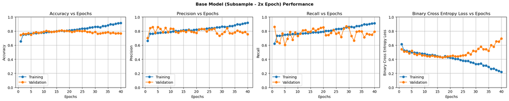

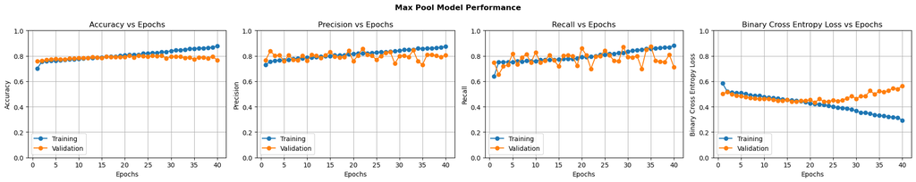

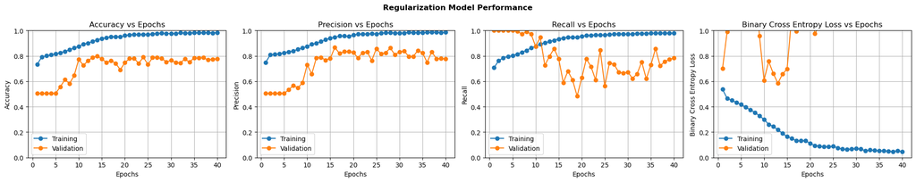

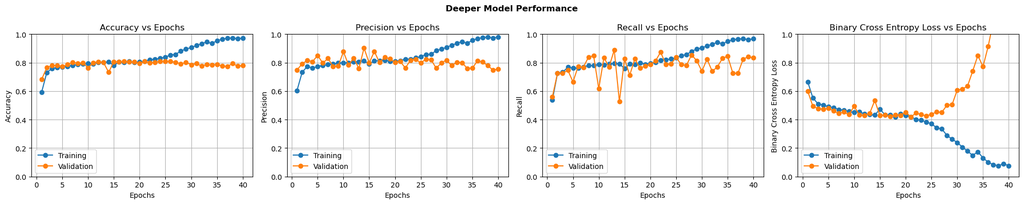

```python
epoch_plots(log_40_1000, suptitle = "Base Model (Subsample - 2x Epoch) Performance")
epoch_plots(max_pool_log, suptitle = "Max Pool Model Performance")
epoch_plots(regularization_log, suptitle = "Regularization Model Performance")
epoch_plots(deep_log, suptitle = "Deeper Model Performance")
```

Since each model represents a variation from the base model, we will review each in turn.

The use of Max Pool as our pooling layer performs very similarly to the base model, achieving similar validation accuracy and begins overfitting between 20 and 25 epochs. Note however that Max Pooling appears to overfit less, as confirmed by a reduced cross entropy loss at 40 epochs. The reduction in overfitting likely results from the loss in parameters when replacing the convolution subsampling layers. The simpler max pooling model without these parameters achieves similar reults, and thus is a superior model to the base model.

The regularization model, typically implemented to reduce overfitting, seemed to dramatically increase overfitting. Remarkably training accuracy improved rapidly compared to the base model, but the validation accuracy did not show a similar increase. The regularization model's recall and binary cross entropy indicated significant instability relative to the base model. While regularization seems generally promising for training improvement, this implementation of regularization may overfit without any distinct decreasing trend in loss. There is a flaw in this variation's experimental design since both dropout and batch normalization were implemented at the same time. As such, their individual effects cannot be isolated as the cause of this poor performance.

The deeper model performs similarly to the base model, also beginning to overfit betwen 20 and 25 epochs. Unsurprisingly, increasing the complexity and parameters in the neural network allows it to overfit more quickly. For example, by the end of training at 40 epochs, the deeper network has 97.4% training accuracy while the base model has a training accuracy of 91%. The overfitting is further apparent in the rise in validation loss, far higher than the base model. Like with max pooling, a simple model with similar results is preferrable to complex models. Thus, the deeper model is inferior to the base model in this application.

## Conclusion

This project seeked to explore several facets of CNN design and assessment.

The project first considered the effects of using a 220,000 point training set against a balanced 50,000 training subsample through 20 epochs. The full data model performed better since it was trained on 4x the samples and had 4x the updates. However, this model suffered from instability near the end of training. This instability and possible overfitting meant the full data and subsample models performed similarly. Smaller subsamples (ex. 1,000) may not be comprehensive for robust training, however small subsamples reduce data preprocessing demands and training demands. Future experiment may evaluate a range of subsample sizes on model accuracy. One may also compare the effects of sample variety vs. repeated exposure to samples. For example, a study could compare 1 epoch of 200,000 training points to 4 epochs of 50,000 training points so the number of backpropagations is the same.

The project also evaluated increasing batch size and epochs. Increasing batch size led to slower accuracy improvements with increased memory demands. The learning reduction is likely due to two factors: 1) fewer updates to the model per epoch, and 2) worse stochastic descent due to averaging larger batches. Larger batches may smooth noisy descents, but it appears the original batch size sufficiently reduced noise. Thus, further increasing batch size did not improve model performance. Increasing training epochs improved the model slightly, though these improvements were lost once the model overfit. The ideal number of epochs gets the model as close to overfitting without overfitting as possible. This analysis reveals the diminishing returns to increasing batch size to smooth noise and the importance of idenfitying the ideal number of epochs to improve a model without overfitting.

Finally, several alternative network architectures were compared to the base model. Replacing convolution subsampling layers with max pooling yielded similar results at reduced model complexity. Regularization, typically designed to reduce overfitting effects, seemed to immediately overfit without a clear decrease in loss through training epochs. Since both batch normalization and dropout were implemented, their individual effects unfortunately cannot be isolated. Future experiments should consider both regularization methods in isolation, especially since the model appeared to train much faster than the base model. A deeper model, adding additional dense layers and more filters to convolutional layers, performed similarly but quickly overfit. Overfitting was likely faster due to the increase in parameters in the deeper model. The increased complexity of the model led to a worse result, and as such is inferior to the base model.

Additional Future work could explore learning rate scheduling to improve model performance, and implement early stopping callbacks to reduce overall training time.

From a project design perspective, it seems valuable to start with an overly simple model that runs quickly. This allows for fast iterations to improve the model, and for the designer to understand the incremental effects of each change. The base model of this project began with 3 convolution structures and a 3 layer dense classification structure, designed relatively arbitrarily. Future development could instead start with a single convolution structure and classification layer. Next it could add one more of each structure separately. Finally the model could add regularization, learning rate reduction, etc. Similarly, hyperparameters could be adjusted for rapid improvement. Batch size might start small to allow for faster training, which can increase if noise becomes concerning. Exploratory projects like this one benefit from very fast, possibly unreliable models (small batches, simple layers, just enough epochs to overfit) early in the process to achieve clear, incremental improvements to model performance.